# NXS TCS Article — Citation Method Comparison

Regex vs LLM (OpenRouter) identification of in-text citations in the definitions

Author

Rainer M. Krug

Published

July 9, 2026

The cited literature is discovered by **extracting in-text citations from the concept definitions** and resolving each to a work in the matching assessment’s reference library. Two extraction methods run as parallel pipeline targets:

- **regex** — a deterministic parser (`R/citation_regex.R`) matching parenthetical and narrative `(Author, year)` forms.
- **llm** — an OpenRouter chat model (`R/extract_definition_citations_llm.R`) reading each definition and returning its citations as JSON.

Both feed the *same* two-pass resolver, so the resolved tables are directly comparable. There is no hand-labelled ground truth, so “better” is judged by three complementary signals:

1. **Volume** — how many citations each finds (a recall proxy).
2. **Agreement** — citations found by *both* are high-confidence; method-only citations are where the methods disagree.
3. **Resolution rate** — the fraction of what each finds that resolves to a real work in the assessment library (a precision proxy: a hallucinated or mis-parsed citation is unlikely to resolve).

# Headline metrics

Table 1: Per method: total citation tokens extracted, how many resolved (strict / loose), resolution %, and distinct works cited. Higher resolution % suggests cleaner extraction; more distinct works = wider cited-literature coverage.

| method | citations | strict | loose | unmatched | resolved % | distinct_works |
| --- | --- | --- | --- | --- | --- | --- |
| llm | 2,581 | 2,129 | 268 | 184 | 92.9 | 1,822 |
| regex | 2,647 | 2,205 | 247 | 195 | 92.6 | 1,826 |

Read this together: the method with **more citations *and* a comparable or higher resolution %** is finding more real citations rather than noise. If one method extracts many more but at a much lower resolution %, the extras are likely spurious (mis-parses or hallucinations that match nothing).

# Agreement per keyset

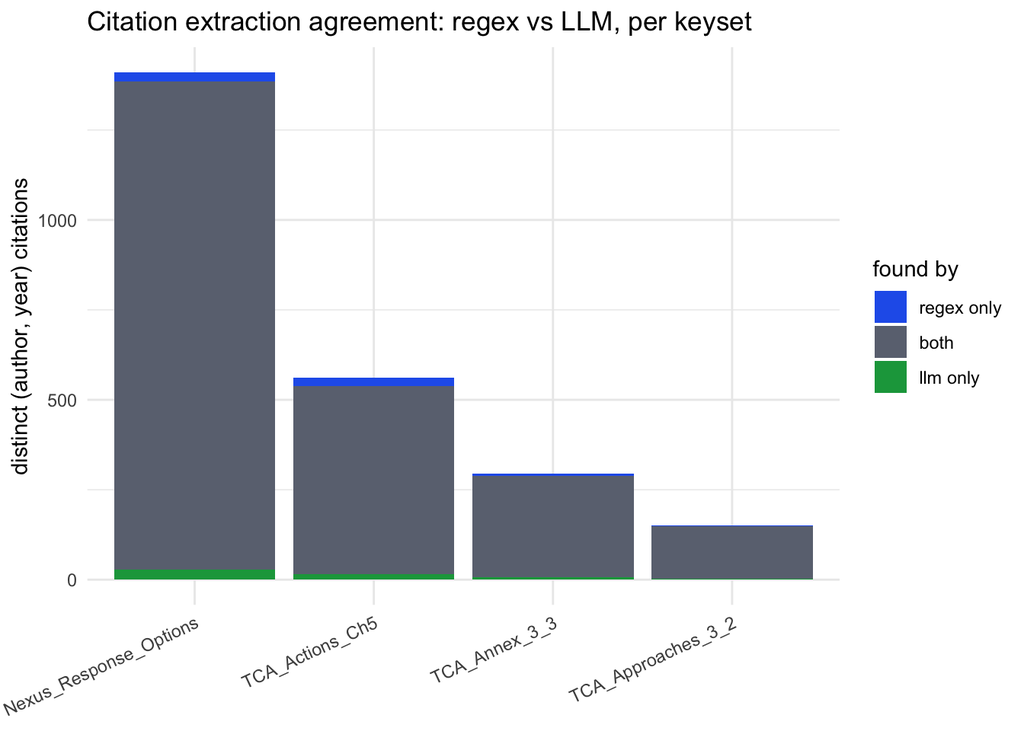

Figure 1: Distinct (author, year) citations per keyset, split by whether they were found by both methods, regex only, or LLM only. A large ‘both’ block = the methods largely agree; large method-only blocks locate systematic differences (e.g. narrative citations, institutional authors).

Table 2: Citation agreement counts per keyset (both / regex only / llm only).

| keyset | both | llm only | regex only | total | agreement % |
| --- | --- | --- | --- | --- | --- |
| Nexus_Response_Options | 1,357 | 27 | 26 | 1,410 | 96.2 |
| TCA_Actions_Ch5 | 523 | 16 | 22 | 561 | 93.2 |
| TCA_Annex_3_3 | 283 | 6 | 5 | 294 | 96.3 |
| TCA_Approaches_3_2 | 145 | 3 | 3 | 151 | 96.0 |

# Citations to review: disagreements & unmatched

Every citation worth a look — either the two methods **disagree** (found by only one), or it stayed **unmatched** (resolved by neither method that found it). Rows found by *both* methods *and* resolved are omitted (nothing to check). Columns: `found_by` (regex only / llm only / both), `resolved`, `pass` (strict / loose / unmatched), and the **actual citation text**. A method-only citation that doesn’t resolve is the least trustworthy — a mis-parse (regex) or an over-eager pickup (LLM); one that does resolve is a genuine citation the other method missed. `both` + unmatched = a real citation neither library contains (often institutional authors, e.g. IUCN / UNFCCC) — the manual verification set. Searchable/sortable:

Table 3

| found_by | resolved | pass | keyset | keypaper_id | raw_citation | author_key | year |
| --- | --- | --- | --- | --- | --- | --- | --- |
| llm only | True | loose | Nexus_Response_Options | B08 | Du Toit &amp; Pettorelli, 2019 | du | 2019 |
| regex only | True | strict | Nexus_Response_Options | B08 | (Du Toit &amp; Pettorelli, 2019) | dutoit | 2019 |
| llm only | True | loose | Nexus_Response_Options | B08 | Van Meerbeek et al., 2019 | van | 2019 |
| regex only | True | strict | Nexus_Response_Options | B08 | (Mikołajczak et al., 2021; Van Meerbeek et al., 2019; Wynne-Jones, 2022) | vanmeerbeek | 2019 |
| llm only | True | loose | Nexus_Response_Options | B13 | La Notte &amp; Rhodes, 2020 | la | 2020 |
| regex only | True | strict | Nexus_Response_Options | B13 | (La Notte &amp; Rhodes, 2020; Vallecillo et al., 2019) | lanotte | 2020 |
| llm only | True | strict | Nexus_Response_Options | B14 | Coffey et al., 2021 | coffey | 2021 |
| llm only | True | strict | Nexus_Response_Options | C01 | Babiker et al., 2022 | babiker | 2022 |
| llm only | True | loose | Nexus_Response_Options | C01 | De Deyn &amp; Kooistra, 2021 | de | 2021 |
| regex only | True | strict | Nexus_Response_Options | C01 | (De Deyn &amp; Kooistra, 2021) | dedeyn | 2021 |

[output cut: 270 more lines]

# Reading the verdict

- If **both** dominates and resolution % is similar, the cheaper, deterministic **regex** method is sufficient — keep `citations.active: regex`.
- If the **LLM** finds materially more citations that *also* resolve at a similar or higher rate (especially narrative citations regex misses), consider switching `citations.active: llm` in `input/config.yaml`.
- Method-only citations that **fail to resolve** are the least trustworthy — weigh a method down if most of its extra finds are unmatched.

# Appendix — how each method identifies citations

## LLM prompt (OpenRouter)

Each definition is sent to the model with the system prompt below (verbatim from `R/extract_definition_citations_llm.R`); the user message is just `TEXT:\n<definition>`, and the reply is parsed as JSON.

**Model:** `anthropic/claude-sonnet-5` — temperature 0, timeout 90s, 6 parallel workers.

[output not shown]

## Regex rules

The regex extractor (`R/citation_regex.R`) has no prompt; it scans each definition for:

- **Parenthetical** groups `( … )` that contain a year, split on `;` into individual citations (e.g. `(Kabeer, 1999; Manlosa, 2022)` → two);
- **Narrative** citations — `Surname (year)`, `Surname et al. (year)`, `A & B (year)`.

In both cases the first-author surname is normalised (lower-cased, diacritics folded, initials / “et al.” dropped) into the `author_key` used for resolution. The year is matched with:

```
(1[6-9][0-9]{2}|20[0-9]{2})[a-z]?
```